# Lab 1: probabilidad y variables aleatorias

Daniel Fernández López, Juan Cordero Pascual, Jesús Joana Azuara

# Objetivos de la práctica

La práctica consiste en una colección de problemas que deberán ser resueltos mediante simulaciones, usando `sample` o bien las funciones `r[name]` asociadas a cada distribución (por ejemplo, `rnorm`). Los objetivos de esta práctica son, por tanto:

- Seguir familiarizándose con el lenguaje `R`.
- Profundizar en el uso de simulaciones para calcular probabilidades.

# Entrega y evaluación

El deadline para la entrega de la práctica se indica en el curso virtual. Cualquier trabajo recibido **fuera del plazo contará como no entregado**. La entrega consistirá, **obligatoriamente, en el fichero de R Markdown con extensión `*.Rmd` y el resultado de compilarlo (un `*.html`).** Ambos ficheros deberán entregarse a través del curso virtual.

Las prácticas que no compilen el fichero `.Rmd` generando un fichero `*.html` válido **no serán evaluadas**.

# Tiempos de bloqueo

Se está monitorizando la confiabilidad de tres ordenadores de un clúster. Sean $X_a$, $X_b$ y $X_c$ los tiempos que transcurren hasta que cada uno de estos ordenadores se bloquean y necesitan reiniciarse. Estos “tiempos de bloqueo” son independientes entre sí y tienen distribuciones exponenciales con parámetros respectivos $\lambda_a = 2, \lambda_b = 3$ y $\lambda_c = 5$. Sea $M$ el instante de tiempo en que el primero de estos ordenadores falla (¡puede ser cualquier de los tres!). Verifica mediante simulaciones que la distribución de M tiene distribución exponencial de parámetro 10. Para ello:

1. Escribe el código necesario para simular la variable $M$. Guarda el resultado de tus simulaciones en la variable `time_sims`. (Pista: las funciones `pmin` o `pmax` pueden ser útiles.)

```r
# M:tiempo hasta que falle el primer ordenador


#Tiempos de Fallo:
#     x_a (tiempo ordenador a) = 2 segundos
#     x_b (tiempo ordenador b) = 3 segundos
#     x_c (tiempo ordenador c) = 5 segundos


simulaciones = 5000
x_a = rexp(simulaciones, rate = 2)
x_b = rexp(simulaciones, rate = 3)
x_c = rexp(simulaciones, rate = 5)
M = pmin(x_a, x_b, x_c)
time_sims <- M
```

2. Estima la distribución a partir de las simulaciones usando un **histograma** (función `hist`; consulta la ayuda para dibujar una densidad de probabilidad en lugar del número de ocurrencias) y…
3. … compara el histograma obtenido con la distribución teórica (la exponencial de parámetro 10). Para ello dibuja en un mismo gráfico la distribución obtenida por simulaciones y la distribución teórica (usando `dexp` y `lines`).

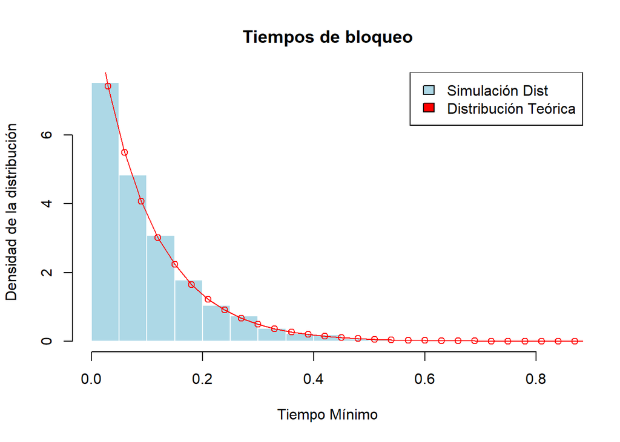

```r
# Histograma para representar la distribución de los tiempos de bloqueo de los tres ordenadores:

hist(M, freq = FALSE, main = "Tiempos de bloqueo", col = "lightblue", border = "white",
     xlab = "Tiempo Mínimo", ylab = "Densidad de la distribución")
x_s = seq(0:max(M), by = 0.03)
lines(x_s, dexp(x_s, rate = 10), col = "red", type="o")
legend("topright", c("Simulación Dist", "Distribución Teórica"), fill = c("lightblue", "red"))
```

```r
# IMPORTANTE: definir "freq" como FALSE para que represente la densidad, en vez de la frecuencia que tiene definida por defecto (TRUE)
```

# James Bond

James Bond está preso en una celda de la que hay tres maneras de escapar: un conducto de aire acondicionado, una tubería de alcantarillado y la puerta (¡cuya cerradura no funciona!). El conducto de aire acondicionado lleva al agente 007 a un viaje de dos horas, después del cual cae de cabeza a través de una trampilla, para diversión de sus captores. La tubería de alcantarillado es similar, pero 007 tarda cinco horas en recorrerla antes de caer por otra trampilla. Cada caída produce amnesia temporal, y 007 es devuelto a la celda. Después de recobrar el conocimiento, James Bond elige inmediatamente una de las tres posibles salidas con probabilidad 1/3. En promedio, ¿cuánto tiempo necesita 007 antes de darse cuenta de que la cerradura de la puerta no funciona?

```r
# VERSIÓN 1:

# Opcion_1 <- conducto ventilación (2 horas)
# Opcion_2 <- alcantarillado       (5 horas)
# Opcion_3 <- puerta (cerradura != funciona)

# Prob eleccion (1/3)
# Tiempo en elegir la opcion 3 (puerta)

tiempoMedio = function(n){
   aire = 2
   alcantarilla = 5
   opciones = c(1:3)
   sims_007 = replicate(n, {
      t = 0
      eleccion = 0
      while (eleccion != 3){
         eleccion = sample(opciones, 1)
         if(eleccion == 1) tiempo = tiempo + aire
         if(eleccion == 2) tiempo = tiempo + alcantarilla
      }
      tiempo
   })
mean(sims_007)
}
```

```r
# VERSIÓN 2:

# Opcion_1 <- conducto ventilación (2 horas)
# Opcion_2 <- alcantarillado       (5 horas)
# Opcion_3 <- puerta (cerradura != funciona)

# Prob eleccion (1/3)
# Tiempo en elegir la opcion 3 (puerta):

opciones = c(1:3)
aire = 2
alcantarilla = 5
tiempo = 0
N = 1000

tiempo_p = replicate(N,{
  eleccion = sample(opciones, 1)
  while (eleccion != 3) {
     if(eleccion == 1) tiempo = tiempo + aire
     if(eleccion == 2) tiempo = tiempo + alcantarilla
     eleccion = sample(opciones, 1)
  }
  tiempo
})
mean(tiempo_p)
```

```
## [1] 7.224
```

# Urnas vacías

Se distribuyen $r$ bolas en $n$ urnas. Estamos interesados en conocer la distribución de la variable aleatoria U: “número de urnas vacías”. Procede como sigue.

1. Escribe una función con prototipo `simulate_u(r, n)` que devuelva una única simulación de U (el número de urnas vacías).

```r
# r: nº de bolas
# n: nº urnas
# U: nº urnas vacías

# Simulación de la variable aleatoria U: "número de urnas vacías"
simulate_u = function(r, n){
  # Representación inicial del nº de urnas (todas vacías)
   urnas = rep(0, n)
   # Distribución de las bolas en las urnas
   for (i in 1:r){
     # Seleccionamos una urna aleatoriamente (sumamos 1 bola)
      urnas[sample(1:n, 1)] = urnas[sample(1:n, 1)] + 1
   }
   # Devolvemos nº de urnas vacías
   sum(urnas == 0)
}
```

2. Generalmente, usamos simulaciones para calcular la probabilidad de un evento en concreto (por ejemplo, para calcular $P(U=2)$). En estas situaciones, tenemos una única definición de evento exitoso. Sin embargo, en este problema queremos calcular $P(U=u)$ para cualquier valor válido de u… ¡y lo queremos hacer llamando una única vez a `replicate`! Esto implica que, para una sola simulación, tendremos que comprobar si la simulación ha sido exitosa para todos los valores válidos de u. Genera una simulación de U y escribe cuáles van a ser tus comprobaciones de “éxito”. Usa, por ejemplo, 10 bolas y 7 urnas.

```r
# r: nº de bolas
# n: nº de urnas
# U: nº de urnas vacías

r = 10
n = 7

prob_urn = function(r, n , u, nb_sims){

  simulations = replicate(nb_sims, {

    urnas = rep(0, n)

    reparto = function(urnas, r, n){
      # Seleccionamos una urna aleatoriamente (sumamos 1 bola)
      j = sample(1:n, 1)
      # Sumamos 1 bola a la urna seleccionada
      urnas = replace(urnas, j, urnas[j]+1)
      urnas
    }

      # Distribución de las bolas en las urnas
      for (i in 1:r){
        urnas = reparto(urnas, r, n)
      }

  # Devolvemos nº de urnas vacías
  sum(sum(urnas==0)==u)
  })

  print(sum(simulations)/nb_sims)
}
```

3. Escribe una función con prototipo `distribution_u(r, n, nb_sims)` que calcule mediante simulaciones la función de probabilidad completa para la variable aleatoria U.

```r
#  Escribe una función con prototipo`distribution_u(r, n, nb_sims)` que calcule mediante simulaciones la función de probabilidad completa para la variable aleatoria U
distribution_u = function(r, n, nb_sims){
  # Vector de urnas vacías
  urnas = 0:n
  # Vector de probabilidades
  probs = rep(0, n+1)
  # Simulaciones
  simulations = replicate(nb_sims, {
    # Representación inicial del nº de urnas (todas vacías)
    urnas = rep(0, n)
    # Distribución de las bolas en las urnas
    for (i in 1:r){
      # Seleccionamos una urna aleatoriamente (sumamos 1 bola)
      urnas[sample(1:n, 1)] = urnas[sample(1:n, 1)] + 1
    }
    # Devolvemos nº de urnas vacías
    sum(urnas == 0)
  })
  # Calculamos la probabilidad de cada valor de urnas vacías
  for (i in 0:n){
    probs[i+1] = sum(simulations == i)/nb_sims
  }
  # Devolvemos la función de probabilidad
  probs
}
```

4. Usa esta función para dibujar la función de probabilidad de la variable aleatoria “nº de urnas vacías si se distribuyen 10 bolas en 7 urnas”.

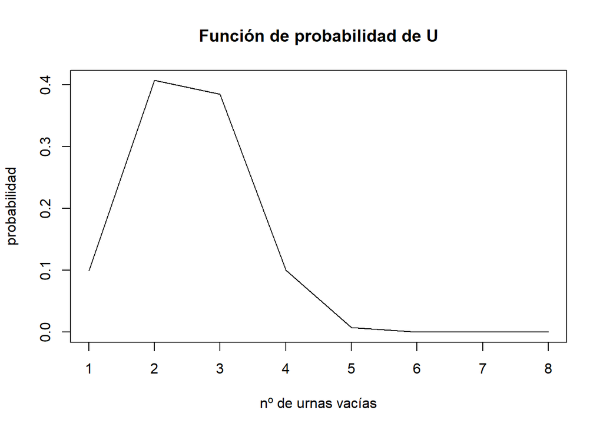

```r
# Usamos la función anterior para dibujar la función de probabilidad de la variable aleatoria "nº de urnas vacías si se distribuyen 10 bolas en 7 urnas"
plot(distribution_u(10, 7, 10000), type = "l", xlab = "nº de urnas vacías", ylab = "probabilidad", main = "Función de probabilidad de U")
```

# Mensajes maliciosos

El siguiente modelo “Binomial-Poisson-Exponencial” de tres etapas se utiliza frecuentemente para modelar el flujo de tráfico en redes y autopistas. Consideremos, por ejemplo, el tráfico de correo electrónico malicioso durante un intervalo de 1 hora (de 12:00 a 13:00, por ejemplo). Las tres etapas de nuestro modelo son las siguientes:

1. El tráfico de correo electrónico total (malicioso o no) varía de un día a otro de forma aleatoria. Para modelar esta variación, podemos asumir que $T$: “ritmo medio de envío de correos electrónicos” tiene distribución exponencial con media 20 $\frac{\text{mensajes}}{\text{hora}}$. ¿Cuál es, por tanto, el parámetro de la exponencial?
2. Sea $M$ la variable aleatoria: “número de mensajes maliciosos enviados durante la hora”. Si el tráfico de correo electrónico malicioso es $T = t$, entonces $M$ tiene distribución de Poisson con parámetro $0.4 t$.
3. No todos los mensajes recibidos $M$ llegan a la bandeja de entrada de nuestros correos electrónicos. De los $M$ mensajes maliciosos recibidos, solo el 12.5% acaban en la bandeja de entrada (gracias a los filtros de spam y otros filtros de seguridad). Sea la variable aleatoria $B$: “nº de mensajes maliciosos que llegan a la bandeja de entrada”.

Nos interesa poder estimar el número de mensajes maliciosos $M$ a partir de $B$. Sigue los siguientes pasos para hacer una estimación mediante simulaciones:

1. Escribe una función `sim_traffic(n_sims)` para generar simulaciones de las tres variables aleatorias del problema. Dado que queremos devolver las tres variables aleatorias para cada simulación, el resultado final debe ser una matriz de $\text{n_sims} \times 3$. Usa la función `cbind` e intenta evitar el uso de `replicate` por eficiencia.

```r
# T: "ritmo medio de envío de correos electrónicos" (exponencial)   --> media = 1/lambda = 20 --> lambda = 1/20
# M: "nº de mensajes maliciosos enviados durante la hora" (poisson) --> lambda = 0.4 * t
# B: "nº de mensajes maliciosos que llegan a la bandeja de entrada" (binomial)

sim_traffic = function(n_sims){
  # Simulación de la variable aleatoria T: "ritmo medio de envío de correos electrónicos"
  t = rexp(n_sims, rate = 1/20)
  # Simulación de la variable aleatoria M: "nº de mensajes maliciosos enviados durante la hora"
  m = rpois(n_sims, lambda = 0.4 * t)
  # Simulación de la variable aleatoria B: "nº de mensajes maliciosos que llegan a la bandeja de entrada"
  b = rbinom(n_sims, size = m, prob = 0.125)
  # Devolvemos las tres variables aleatorias (matriz)
  cbind(b, m, t)
}
```

2. Para nuestros objetivo final, la variable $T$ no es útil, por lo que debemos marginalizarla. Marginalizar por simulaciones es sencillo. En vez de devolver `c(b, m, t)` basta con ignorar `t` y devolver `c(b, m)`. Escribe `sim_messages(n_sims)` para generar simulaciones de las variables $B$ y $M$. (Ten en cuenta que copiar y pegar código es un crimen contra la humanidad penado por los tribunales internacionales.)

```r
# Marginalizamos la t
sim_messages = function(n_sims){
  marginalizacion_t = sim_traffic(n_sims)[, c(1, 2)]
  marginalizacion_t
}
```

3. Hoy hemos recibido en nuestra bandeja de entrada $B=b$ mensajes maliciosos. Para estimar $M$ a partir de esta información, calcularemos $P(M=m|B=b).$ Escribe la función `p_m_given_b(m, b, n_sims=10000)` para calcular esta probabilidad condicional usando simulaciones. (Recuerda que, tal y como se vio en clase, a la hora de calcular probabilidades condicionadas tenemos dos condiciones de éxito.)

```r
# calcula la probabilidad condicionada P(M=m|B=b)
p_m_given_b = function(m, b, n_sims=10000){
  # Simulamos las variables aleatorias B y M
  simulaciones = sim_messages(n_sims)
  # Calculamos la probabilidad condicionada (dos condiciones de éxito)
  condicion_numerador = sum(simulaciones[, 1] == b & simulaciones[, 2] == m)
  condicion_denominador = sum(simulaciones[, 1] == b)
  condicion_numerador / condicion_denominador
}
```

4. Imaginemos que hemos recibido $B=2$ mensajes maliciosos en nuestro correo. Dibuja, empleando la función anterior, $P(M=m|b=2)$ y halla cuál es el valor de $M$ más probable (la moda). Para hacer el plot, vectoriza previamente la función con `Vectorize` y usa un gran número de simulaciones.

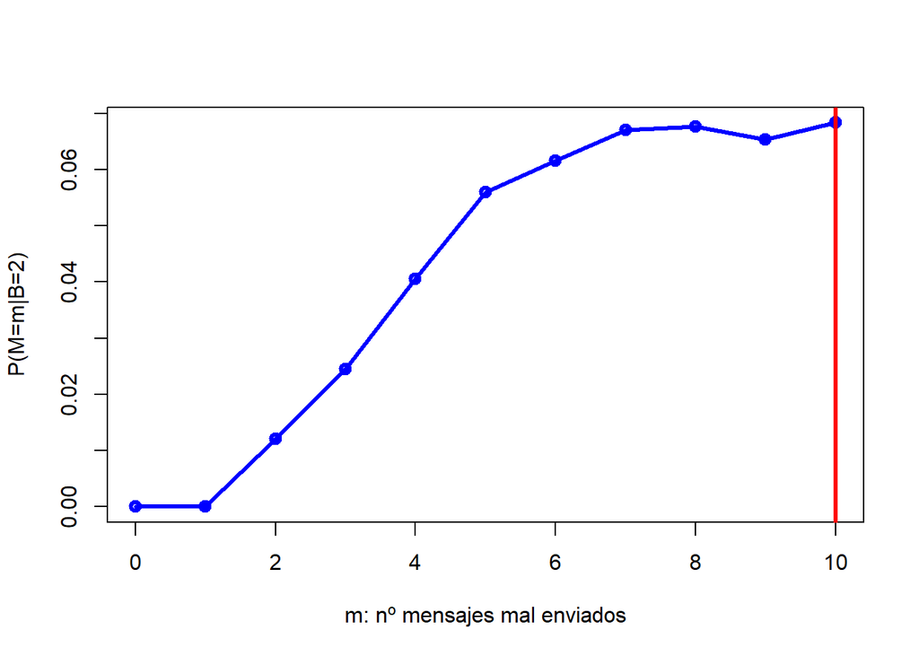

```r
# Vectorizamos la función
p_m_given_b_vectorizada = Vectorize(p_m_given_b)

# Calculamos la moda (valor más probable)
moda = which.max(p_m_given_b_vectorizada(0:10, 2, n_sims = 100000))

# Dibujamos la probabilidad condicionada (probabilidad de que de m mensajes maliciosos enviados, 2 llegen a la bandeja de entrada)
plot(0:10, p_m_given_b_vectorizada(0:10, 2, n_sims = 100000), type = "o", lwd = 3, col = "blue", xlab = "m: nº mensajes mal enviados", ylab = "P(M=m|B=2)")
abline(v = moda, col = "red", lwd = 3)
```

# (VOLUNTARIO) El problema del secretario

Este problema, conocido como el problema del secretario, apareció en la columna de problemas matemáticas de Martin Gardner, en *Scientific American*. Originalmente, el enunciado trataba de encontrar la estrategia óptima para que un directivo eligiese de forma óptima al secretario más competente entre un grupo de $n$ candidatos. Sin embargo, también se ha aplicado a muchos otros casos interesantes, incluyendo el cálculo del número de citas (con personas distintas) que debes de tener antes de “sentar la cabeza” y maximizar tus probabilidades de elegir a tu marido/esposa ideal. En lo que sigue, nosotros formulamos el problema en términos de una lista de n números.

En $n$ trozos de papel, escribimos $n$ números distintos (que pueden tomar cualquier valor positivo). Sea $M$ es el número más grande. El juego consiste en que se te irán mostrando los trozos de papel uno a uno, y tu tienes que decidir si quedarte con el número que ves (y el juego acaba) o si lo rechazas y pides otro número. Una vez rechazado un número, no puedes volver atrás y elegir un número ya visto (¿puedes ver el paralelismo con las citas?). Tu objetivo es elegir el número más grande, $M$. Ten en cuenta que cuando se te enseña el número k-ésimo, sólo cuentas con la información relativa a los $k-1$ números anteriores.

Aunque el problema es difícil, existe una estrategia que da buenos resultados: Para algún número $r$ entre 0 y n, rechazas los $r$ primeros números y luego seleccionas el primer número que sea mejor que los primeros $r$. Sigue los siguientes pasos para resolver el problema:

1. Implementa las funciones necesarias para simular esta estrategia para cualquier $r$ y cualquier $n$:
- `simulate_game`: recibe `r` y `n` y simula una sola realización del juego. Devuelve `TRUE` si se acierta $M$ y `FALSE` en caso contrario.
- `estimate_probability`: recibe `r`, `n` y `nb_sims` (número de simulaciones) y hace uso de la función `simulate_game` para calcular la probabilidad de acertar $M$ usando la estrategia de rechazar los $r$ primeros.

```r
# n: número de trozos de papel
# r: número de trozos de papel que rechazamos
# M: número más grande

simulate_game = function(r, n){
  # Numeros escritos en los trozos de papel
  numeros = sample(1:100, n, replace = FALSE)
  # Seleccionamos los r primeros elementos
  numeros_rechazados = numeros[1:r]
  # Eliminamos los r primeros elementos
  numeros_restantes = numeros[-(1:r)]
  # Comprobamos si el número restante es el más grande (M) o no
  max(numeros_restantes) == max(numeros)
}

estimate_probability = function(r, n, nb_sims = 10000){
  # Simulamos el juego nb_sims veces
  simulaciones = replicate(nb_sims, simulate_game(r, n))
  # Calculamos la probabilidad de acertar M
  sum(simulaciones) / nb_sims
}
```

2. Aplica tus funciones al caso $n$ = 20 y calcula las probabilidades, $p_r$, de acertar $M$ con la estrategia de rechazar los $r$ primeros números para todo número $r$ válido.
3. Dibuja $p_r$ Vs. $r$.

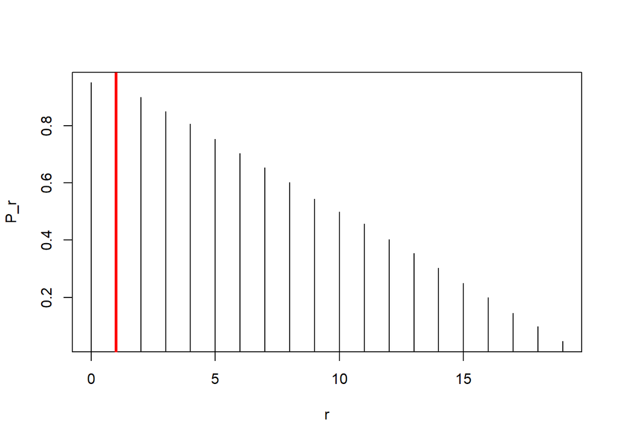

```r
# b)
n = 20
p_r = c()
for (r in 0:19) {
  p_r [r+1]= estimate_probability(r, n, nb_sims = 10000)
}

# c)
plot(0:19, p_r, type = "h", xlab = "r", ylab = "P_r")
abline(v = which.max(p_r), col = "red", lwd = 3)
```

4. En base al gráfico anterior, ¿cuál es la mejor estrategia para $n=20$? ¿Cuál es la probabilidad de acertar $M$ con esta estrategia?